# STAT/MATH 495: Problem Set 04

Meredith Manley

2017-10-03

# Collaboration

Please indicate who you collaborated with on this assignment:

# Load packages, data, model formulas

```r
library(tidyverse)
credit <- read_csv("http://www-bcf.usc.edu/~gareth/ISL/Credit.csv") %>%
  select(-X1) %>%
  mutate(ID = 1:n()) %>%
  select(ID, Balance, Income, Limit, Rating, Age, Cards, Education)
```

```r
model1_formula <- as.formula("Balance ~ 1")
model2_formula <- as.formula("Balance ~ Income")
model3_formula <- as.formula("Balance ~ Income + Limit")
model4_formula <- as.formula("Balance ~ Income + Limit + Rating")
model5_formula <- as.formula("Balance ~ Income + Limit + Rating + Age")
model6_formula <- as.formula("Balance ~ Income + Limit + Rating + Age + Cards")
model7_formula <- as.formula("Balance ~ Income + Limit + Rating + Age + Cards + Education")
```

> We can expect that when calculating the RMSE from predictions using the training data that it will be lower than the RMSE from predictions using the testing data (aka indicates a more accurate model) because the model is fit to meet the characteristics of the training data, thus the predictions will be a better representation of the training data, but not necessarily the entire population. With a lower RMSE score we can assume that we are not overfitting or underfitting the data with our model, which is ideal.

#### model1

```r
model1 <- lm(model1_formula, data=credit_train)

# extract regression table in tidy format
model1 %>%
  broom::tidy()

# extract point-by-point info in tidy format
model1 %>%
  broom::augment() %>%
  head()

# extract summary stats info in tidy format
model1 %>%
  broom::glance()

# generate y_hat on test data- saved as a dataframe
y_hat <- predict(model1, newdata=credit_test) %>%
  tibble::as.tibble()

# convert y_hat to a vector and add y_hat to test dataset
y_hat <- y_hat$value

# report RMSE on test data
RMSE1 <- credit_test %>%
  mutate(y_hat = y_hat) %>%
  mutate(epsilon = Balance - y_hat) %>%
  mutate(MSE = mean((Balance - y_hat)^2)) %>%
  mutate(RMSE = sqrt(MSE)) %>%
  summarise(mean(RMSE))

RMSE1 <- as.numeric(RMSE1)

# generate y_hat on training data - saved as a dataframe
y_hat <- predict(model1, newdata=credit_train) %>%
  tibble::as.tibble()

# convert y_hat to a vector and add y_hat to training dataset
y_hat <- y_hat$value

# report RMSE on training data
RMSE1t <- credit_train %>%
  mutate(y_hat = y_hat) %>%
  mutate(epsilon = Balance - y_hat) %>%
  mutate(MSE = mean((Balance - y_hat)^2)) %>%
  mutate(RMSE = sqrt(MSE)) %>%
  summarise(mean(RMSE))

RMSE1t <- as.numeric(RMSE1t)
```

#### model2

```r
model2 <- lm(model2_formula, data=credit_train)

# extract regression table in tidy format
model2 %>%
  broom::tidy()

# extract point-by-point info in tidy format
model2 %>%
  broom::augment() %>%
  head()

# extract summary stats info in tidy format
model2 %>%
  broom::glance()

# generate y_hat on test data- saved as a dataframe
y_hat <- predict(model2, newdata = credit_test) %>%
  tibble::as.tibble()

# convert y_hat to a vector and add y_hat to test dataset
y_hat <- y_hat$value

# report RMSE on test data
RMSE2 <- credit_test %>%
  mutate(y_hat = y_hat) %>%
  mutate(epsilon = Balance - y_hat) %>%
  mutate(MSE = mean((Balance - y_hat)^2)) %>%
  mutate(RMSE = sqrt(MSE)) %>%
  summarise(mean(RMSE))

RMSE2 <- as.numeric(RMSE2)

# generate y_hat on training data- saved as a dataframe
y_hat <- predict(model2, newdata = credit_train) %>%
  tibble::as.tibble()

# convert y_hat to a vector and add y_hat to training dataset
y_hat <- y_hat$value

# report RMSE on train data
RMSE2t <- credit_train %>%
  mutate(y_hat = y_hat) %>%
  mutate(epsilon = Balance - y_hat) %>%
  mutate(MSE = mean((Balance - y_hat)^2)) %>%
  mutate(RMSE = sqrt(MSE)) %>%
  summarise(mean(RMSE))

RMSE2t <- as.numeric(RMSE2t)
```

#### model3

```r
model3 <- lm(model3_formula, data=credit_train)

# extract regression table in tidy format
model3 %>%
  broom::tidy()

# extract point-by-point info in tidy format
model3 %>%
  broom::augment() %>%
  head()

# extract summary stats info in tidy format
model3 %>%
  broom::glance()

# generate y_hat on test data - saved as a dataframe
y_hat <- predict(model3, newdata = credit_test) %>%
  tibble::as.tibble()

# convert y_hat to a vector and add y_hat to test dataset
y_hat <- y_hat$value

# report RMSE on test data
RMSE3 <- credit_test %>%
  mutate(y_hat = y_hat) %>%
  mutate(epsilon = Balance - y_hat) %>%
  mutate(MSE = mean((Balance - y_hat)^2)) %>%
  mutate(RMSE = sqrt(MSE)) %>%
  summarise(mean(RMSE))

RMSE3 <- as.numeric(RMSE3)

# generate y_hat on training data - saved as a dataframe
y_hat <- predict(model3, newdata = credit_train) %>%
  tibble::as.tibble()

# convert y_hat to a vector and add y_hat to training dataset
y_hat <- y_hat$value

# report RMSE on train data
RMSE3t <- credit_train %>%
  mutate(y_hat = y_hat) %>%
  mutate(epsilon = Balance - y_hat) %>%
  mutate(MSE = mean((Balance - y_hat)^2)) %>%
  mutate(RMSE = sqrt(MSE)) %>%
  summarise(mean(RMSE))

RMSE3t <- as.numeric(RMSE3t)
```

#### model4

```r
model4 <- lm(model4_formula, data=credit_train)

# extract regression table in tidy format
model2 %>%
  broom::tidy()

# extract point-by-point info in tidy format
model2 %>%
  broom::augment() %>%
  head()

# extract summary stats info in tidy format
model4 %>%
  broom::glance()

# generate y_hat on test data- saved as a dataframe
y_hat <- predict(model4, newdata = credit_test) %>%
  tibble::as.tibble()

# convert y_hat to a vector and add y_hat to test dataset
y_hat <- y_hat$value

# report RMSE on test data
RMSE4 <- credit_test %>%
  mutate(y_hat = y_hat) %>%
  mutate(epsilon = Balance - y_hat) %>%
  mutate(MSE = mean((Balance - y_hat)^2)) %>%
  mutate(RMSE = sqrt(MSE)) %>%
  summarise(mean(RMSE))

RMSE4 <- as.numeric(RMSE4)

# generate y_hat on training data- saved as a dataframe
y_hat <- predict(model4, newdata = credit_train) %>%
  tibble::as.tibble()

# convert y_hat to a vector and add y_hat to training dataset
y_hat <- y_hat$value

# report RMSE on train data
RMSE4t <- credit_train %>%
  mutate(y_hat = y_hat) %>%
  mutate(epsilon = Balance - y_hat) %>%
  mutate(MSE = mean((Balance - y_hat)^2)) %>%
  mutate(RMSE = sqrt(MSE)) %>%
  summarise(mean(RMSE))

RMSE4t <- as.numeric(RMSE4t)
```

#### model5

```r
model5 <- lm(model5_formula, data=credit_train)

# extract regression table in tidy format
model5 %>%
  broom::tidy()

# extract point-by-point info in tidy format
model5 %>%
  broom::augment() %>%
  head()

# extract summary stats info in tidy format
model5 %>%
  broom::glance()

# generate y_hat on test data - saved as a dataframe
y_hat <- predict(model5, newdata = credit_test) %>%
  tibble::as.tibble()

# convert y_hat to a vector and add y_hat to test dataset
y_hat <- y_hat$value

# report RMSE on test data
RMSE5 <- credit_test %>%
  mutate(y_hat = y_hat) %>%
  mutate(epsilon = Balance - y_hat) %>%
  mutate(MSE = mean((Balance - y_hat)^2)) %>%
  mutate(RMSE = sqrt(MSE)) %>%
  summarise(mean(RMSE))

RMSE5 <- as.numeric(RMSE5)

# generate y_hat on training data - saved as a dataframe
y_hat <- predict(model5, newdata = credit_train) %>%
  tibble::as.tibble()

# convert y_hat to a vector and add y_hat to training dataset
y_hat <- y_hat$value

# report RMSE on train data
RMSE5t <- credit_train %>%
  mutate(y_hat = y_hat) %>%
  mutate(epsilon = Balance - y_hat) %>%
  mutate(MSE = mean((Balance - y_hat)^2)) %>%
  mutate(RMSE = sqrt(MSE)) %>%
  summarise(mean(RMSE))

RMSE5t <- as.numeric(RMSE5t)
```

#### model6

```r
model6 <- lm(model6_formula, data=credit_train)

# extract regression table in tidy format
model6 %>%
  broom::tidy()

# extract point-by-point info in tidy format
model6 %>%
  broom::augment() %>%
  head()

# extract summary stats info in tidy format
model6 %>%
  broom::glance()

# generate y_hat on test data - saved as a dataframe
y_hat <- predict(model6, newdata = credit_test) %>%
  tibble::as.tibble()

# convert y_hat to a vector and add y_hat to test dataset
y_hat <- y_hat$value

# report RMSE on test data
RMSE6 <- credit_test %>%
  mutate(y_hat = y_hat) %>%
  mutate(epsilon = Balance - y_hat) %>%
  mutate(MSE = mean((Balance - y_hat)^2)) %>%
  mutate(RMSE = sqrt(MSE)) %>%
  summarise(mean(RMSE))

RMSE6 <- as.numeric(RMSE6)

# generate y_hat on training data - saved as a dataframe
y_hat <- predict(model6, newdata = credit_train) %>%
  tibble::as.tibble()

# convert y_hat to a vector and add y_hat to training dataset
y_hat <- y_hat$value

# report RMSE on train data
RMSE6t <- credit_train %>%
  mutate(y_hat = y_hat) %>%
  mutate(epsilon = Balance - y_hat) %>%
  mutate(MSE = mean((Balance - y_hat)^2)) %>%
  mutate(RMSE = sqrt(MSE)) %>%
  summarise(mean(RMSE))

RMSE6t <- as.numeric(RMSE6t)
```

#### model7

```r
model7 <- lm(model7_formula, data=credit_train)

# extract regression table in tidy format
model7 %>%
  broom::tidy()

# extract point-by-point info in tidy format
model7 %>%
  broom::augment() %>%
  head()

# extract summary stats info in tidy format
model7 %>%
  broom::glance()

# generate y_hat on test data - saved as a dataframe
y_hat <- predict(model7, newdata = credit_test) %>%
  tibble::as.tibble()

# convert y_hat to a vector and add y_hat to test dataset
y_hat <- y_hat$value

# report RMSE on test data
RMSE7 <- credit_test %>%
  mutate(y_hat = y_hat) %>%
  mutate(epsilon = Balance - y_hat) %>%
  mutate(MSE = mean((Balance - y_hat)^2)) %>%
  mutate(RMSE = sqrt(MSE)) %>%
  summarise(mean(RMSE))

RMSE7 <- as.numeric(RMSE7)

# generate y_hat on training data - saved as a dataframe
y_hat <- predict(model7, newdata = credit_train) %>%
  tibble::as.tibble()

# convert y_hat to a vector and add y_hat to training dataset
y_hat <- y_hat$value

# report RMSE on train data
RMSE7t <- credit_train %>%
  mutate(y_hat = y_hat) %>%
  mutate(epsilon = Balance - y_hat) %>%
  mutate(MSE = mean((Balance - y_hat)^2)) %>%
  mutate(RMSE = sqrt(MSE)) %>%
  summarise(mean(RMSE))

RMSE7t <- as.numeric(RMSE7t)
```

## RMSE vs. Number of Coefficients

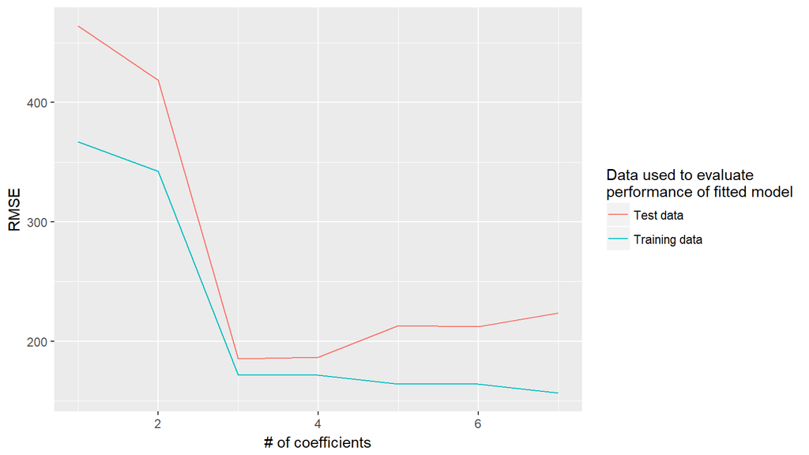

```r
RMSE_train <- c(RMSE1t, RMSE2t, RMSE3t, RMSE4t, RMSE5t, RMSE6t, RMSE7t)
RMSE_test <- c(RMSE1, RMSE2, RMSE3, RMSE4, RMSE5, RMSE6, RMSE7)

# Save results in a data frame. Note this data frame is in wide format.
results <- data.frame(
  num_coefficients = 1:7,
  RMSE_train,
  RMSE_test
)

# Some cleaning of results
results <- results %>%
  # More intuitive names:
  rename(
    `Training data` = RMSE_train,
    `Test data` = RMSE_test
  ) %>%
  # Convert results data frame to "tidy" data format i.e. long format, so that we
  # can ggplot it
  gather(type, RMSE, -num_coefficients)

ggplot(results, aes(x=num_coefficients, y=RMSE, col=type)) +
  geom_line() +
  labs(x="# of coefficients", y="RMSE", col="Data used to evaluate \nperformance of fitted model")
```

# Interpret the graph

Compare and contrast the two curves and hypothesize as to the root cause of any differences.

# Bonus

Repeat the whole process, but let `credit_train` be a random sample of size 380 from `credit` instead of 20. Now compare and contrast this graph with the one above and hypothesize as to the root cause of any differences.

```r
set.seed(79)
credit_train <- credit %>%
  sample_n(380)
credit_test <- credit %>%
  anti_join(credit_train, by="ID")
```

#### model1

```r
model1 <- lm(model1_formula, data=credit_train)

# extract regression table in tidy format
model1 %>%
  broom::tidy()

# extract point-by-point info in tidy format
model1 %>%
  broom::augment() %>%
  head()

# extract summary stats info in tidy format
model1 %>%
  broom::glance()

# generate y_hat on test data- saved as a dataframe
y_hat <- predict(model1, newdata=credit_test) %>%
  tibble::as.tibble()

# convert y_hat to a vector and add y_hat to test dataset
y_hat <- y_hat$value

# report RMSE on test data
RMSE1 <- credit_test %>%
  mutate(y_hat = y_hat) %>%
  mutate(epsilon = Balance - y_hat) %>%
  mutate(MSE = mean((Balance - y_hat)^2)) %>%
  mutate(RMSE = sqrt(MSE)) %>%
  summarise(mean(RMSE))

RMSE1 <- as.numeric(RMSE1)

# generate y_hat on training data - saved as a dataframe
y_hat <- predict(model1, newdata=credit_train) %>%
  tibble::as.tibble()

# convert y_hat to a vector and add y_hat to training dataset
y_hat <- y_hat$value

# report RMSE on training data
RMSE1t <- credit_train %>%
  mutate(y_hat = y_hat) %>%
  mutate(epsilon = Balance - y_hat) %>%
  mutate(MSE = mean((Balance - y_hat)^2)) %>%
  mutate(RMSE = sqrt(MSE)) %>%
  summarise(mean(RMSE))

RMSE1t <- as.numeric(RMSE1t)
```

#### model2

```r
model2 <- lm(model2_formula, data=credit_train)

# extract regression table in tidy format
model2 %>%
  broom::tidy()

# extract point-by-point info in tidy format
model2 %>%
  broom::augment() %>%
  head()

# extract summary stats info in tidy format
model2 %>%
  broom::glance()

# generate y_hat on test data- saved as a dataframe
y_hat <- predict(model2, newdata = credit_test) %>%
  tibble::as.tibble()

# convert y_hat to a vector and add y_hat to test dataset
y_hat <- y_hat$value

# report RMSE on test data
RMSE2 <- credit_test %>%
  mutate(y_hat = y_hat) %>%
  mutate(epsilon = Balance - y_hat) %>%
  mutate(MSE = mean((Balance - y_hat)^2)) %>%
  mutate(RMSE = sqrt(MSE)) %>%
  summarise(mean(RMSE))

RMSE2 <- as.numeric(RMSE2)

# generate y_hat on training data- saved as a dataframe
y_hat <- predict(model2, newdata = credit_train) %>%
  tibble::as.tibble()

# convert y_hat to a vector and add y_hat to training dataset
y_hat <- y_hat$value

# report RMSE on train data
RMSE2t <- credit_train %>%
  mutate(y_hat = y_hat) %>%
  mutate(epsilon = Balance - y_hat) %>%
  mutate(MSE = mean((Balance - y_hat)^2)) %>%
  mutate(RMSE = sqrt(MSE)) %>%
  summarise(mean(RMSE))

RMSE2t <- as.numeric(RMSE2t)
```

#### model3

```r
model3 <- lm(model3_formula, data=credit_train)

# extract regression table in tidy format
model3 %>%
  broom::tidy()

# extract point-by-point info in tidy format
model3 %>%
  broom::augment() %>%
  head()

# extract summary stats info in tidy format
model3 %>%
  broom::glance()

# generate y_hat on test data - saved as a dataframe
y_hat <- predict(model3, newdata = credit_test) %>%
  tibble::as.tibble()

# convert y_hat to a vector and add y_hat to test dataset
y_hat <- y_hat$value

# report RMSE on test data
RMSE3 <- credit_test %>%
  mutate(y_hat = y_hat) %>%
  mutate(epsilon = Balance - y_hat) %>%
  mutate(MSE = mean((Balance - y_hat)^2)) %>%
  mutate(RMSE = sqrt(MSE)) %>%
  summarise(mean(RMSE))

RMSE3 <- as.numeric(RMSE3)

# generate y_hat on training data - saved as a dataframe
y_hat <- predict(model3, newdata = credit_train) %>%
  tibble::as.tibble()

# convert y_hat to a vector and add y_hat to training dataset
y_hat <- y_hat$value

# report RMSE on train data
RMSE3t <- credit_train %>%
  mutate(y_hat = y_hat) %>%
  mutate(epsilon = Balance - y_hat) %>%
  mutate(MSE = mean((Balance - y_hat)^2)) %>%
  mutate(RMSE = sqrt(MSE)) %>%
  summarise(mean(RMSE))

RMSE3t <- as.numeric(RMSE3t)
```

#### model4

```r
model4 <- lm(model4_formula, data=credit_train)

# extract regression table in tidy format
model2 %>%
  broom::tidy()

# extract point-by-point info in tidy format
model2 %>%
  broom::augment() %>%
  head()

# extract summary stats info in tidy format
model4 %>%
  broom::glance()

# generate y_hat on test data- saved as a dataframe
y_hat <- predict(model4, newdata = credit_test) %>%
  tibble::as.tibble()

# convert y_hat to a vector and add y_hat to test dataset
y_hat <- y_hat$value

# report RMSE on test data
RMSE4 <- credit_test %>%
  mutate(y_hat = y_hat) %>%
  mutate(epsilon = Balance - y_hat) %>%
  mutate(MSE = mean((Balance - y_hat)^2)) %>%
  mutate(RMSE = sqrt(MSE)) %>%
  summarise(mean(RMSE))

RMSE4 <- as.numeric(RMSE4)

# generate y_hat on training data- saved as a dataframe
y_hat <- predict(model4, newdata = credit_train) %>%
  tibble::as.tibble()

# convert y_hat to a vector and add y_hat to training dataset
y_hat <- y_hat$value

# report RMSE on train data
RMSE4t <- credit_train %>%
  mutate(y_hat = y_hat) %>%
  mutate(epsilon = Balance - y_hat) %>%
  mutate(MSE = mean((Balance - y_hat)^2)) %>%
  mutate(RMSE = sqrt(MSE)) %>%
  summarise(mean(RMSE))

RMSE4t <- as.numeric(RMSE4t)
```

#### model5

```r
model5 <- lm(model5_formula, data=credit_train)

# extract regression table in tidy format
model5 %>%
  broom::tidy()

# extract point-by-point info in tidy format
model5 %>%
  broom::augment() %>%
  head()

# extract summary stats info in tidy format
model5 %>%
  broom::glance()

# generate y_hat on test data - saved as a dataframe
y_hat <- predict(model5, newdata = credit_test) %>%
  tibble::as.tibble()

# convert y_hat to a vector and add y_hat to test dataset
y_hat <- y_hat$value

# report RMSE on test data
RMSE5 <- credit_test %>%
  mutate(y_hat = y_hat) %>%
  mutate(epsilon = Balance - y_hat) %>%
  mutate(MSE = mean((Balance - y_hat)^2)) %>%
  mutate(RMSE = sqrt(MSE)) %>%
  summarise(mean(RMSE))

RMSE5 <- as.numeric(RMSE5)

# generate y_hat on training data - saved as a dataframe
y_hat <- predict(model5, newdata = credit_train) %>%
  tibble::as.tibble()

# convert y_hat to a vector and add y_hat to training dataset
y_hat <- y_hat$value

# report RMSE on train data
RMSE5t <- credit_train %>%
  mutate(y_hat = y_hat) %>%
  mutate(epsilon = Balance - y_hat) %>%
  mutate(MSE = mean((Balance - y_hat)^2)) %>%
  mutate(RMSE = sqrt(MSE)) %>%
  summarise(mean(RMSE))

RMSE5t <- as.numeric(RMSE5t)
```

#### model6

```r
model6 <- lm(model6_formula, data=credit_train)

# extract regression table in tidy format
model6 %>%
  broom::tidy()

# extract point-by-point info in tidy format
model6 %>%
  broom::augment() %>%
  head()

# extract summary stats info in tidy format
model6 %>%
  broom::glance()

# generate y_hat on test data - saved as a dataframe
y_hat <- predict(model6, newdata = credit_test) %>%
  tibble::as.tibble()

# convert y_hat to a vector and add y_hat to test dataset
y_hat <- y_hat$value

# report RMSE on test data
RMSE6 <- credit_test %>%
  mutate(y_hat = y_hat) %>%
  mutate(epsilon = Balance - y_hat) %>%
  mutate(MSE = mean((Balance - y_hat)^2)) %>%
  mutate(RMSE = sqrt(MSE)) %>%
  summarise(mean(RMSE))

RMSE6 <- as.numeric(RMSE6)

# generate y_hat on training data - saved as a dataframe
y_hat <- predict(model6, newdata = credit_train) %>%
  tibble::as.tibble()

# convert y_hat to a vector and add y_hat to training dataset
y_hat <- y_hat$value

# report RMSE on train data
RMSE6t <- credit_train %>%
  mutate(y_hat = y_hat) %>%
  mutate(epsilon = Balance - y_hat) %>%
  mutate(MSE = mean((Balance - y_hat)^2)) %>%
  mutate(RMSE = sqrt(MSE)) %>%
  summarise(mean(RMSE))

RMSE6t <- as.numeric(RMSE6t)
```

#### model7

```r
model7 <- lm(model7_formula, data=credit_train)

# extract regression table in tidy format
model7 %>%
  broom::tidy()

# extract point-by-point info in tidy format
model7 %>%
  broom::augment() %>%
  head()

# extract summary stats info in tidy format
model7 %>%
  broom::glance()

# generate y_hat on test data - saved as a dataframe
y_hat <- predict(model7, newdata = credit_test) %>%
  tibble::as.tibble()

# convert y_hat to a vector and add y_hat to test dataset
y_hat <- y_hat$value

# report RMSE on test data
RMSE7 <- credit_test %>%
  mutate(y_hat = y_hat) %>%
  mutate(epsilon = Balance - y_hat) %>%
  mutate(MSE = mean((Balance - y_hat)^2)) %>%
  mutate(RMSE = sqrt(MSE)) %>%
  summarise(mean(RMSE))

RMSE7 <- as.numeric(RMSE7)

# generate y_hat on training data - saved as a dataframe
y_hat <- predict(model7, newdata = credit_train) %>%
  tibble::as.tibble()

# convert y_hat to a vector and add y_hat to training dataset
y_hat <- y_hat$value

# report RMSE on train data
RMSE7t <- credit_train %>%
  mutate(y_hat = y_hat) %>%
  mutate(epsilon = Balance - y_hat) %>%
  mutate(MSE = mean((Balance - y_hat)^2)) %>%
  mutate(RMSE = sqrt(MSE)) %>%
  summarise(mean(RMSE))

RMSE7t <- as.numeric(RMSE7t)
```

## RMSE vs. Number of Coefficients

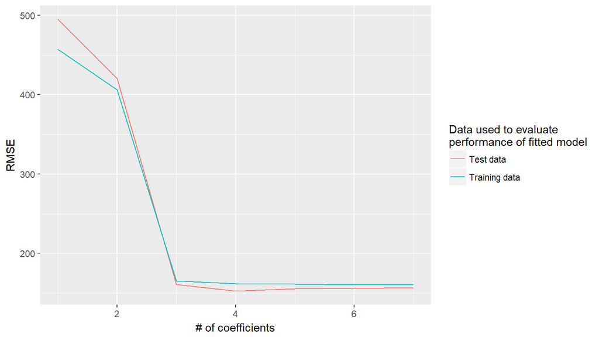

```r
RMSE_train <- c(RMSE1t, RMSE2t, RMSE3t, RMSE4t, RMSE5t, RMSE6t, RMSE7t)
RMSE_test <- c(RMSE1, RMSE2, RMSE3, RMSE4, RMSE5, RMSE6, RMSE7)

# Save results in a data frame. Note this data frame is in wide format.
results <- data.frame(
  num_coefficients = 1:7,
  RMSE_train,
  RMSE_test
)

# Some cleaning of results
results <- results %>%
  # More intuitive names:
  rename(
    `Training data` = RMSE_train,
    `Test data` = RMSE_test
  ) %>%
  # Convert results data frame to "tidy" data format i.e. long format, so that we
  # can ggplot it
  gather(type, RMSE, -num_coefficients)

ggplot(results, aes(x=num_coefficients, y=RMSE, col=type)) +
  geom_line() +
  labs(x="# of coefficients", y="RMSE", col="Data used to evaluate \nperformance of fitted model")
```

# Interpret the graph

Compare and contrast the two curves and hypothesize as to the root cause of any differences.

> The two curves are fairly similar, however, we see slight differences for all numbers of coefficients except 3. For 1 and 2 coefficients the RMSE obtained using the testing data is higher than the blue line indicating that the training data was used to evaluate the performance of the fitted model, which follows the pattern we observed in the previous plot. For number of coefficients 4 to 7 we see that the blue line is higher than the red line. These lines might be closer because of the fact that more observations were used to fit a model in this instance than the amount used for the previous model. This results in a model that is more representative of the data and thus a more accurate model in terms of prediction.